# Visual Information

Information & Interaction Design

Mick McQuaid

mcq@utexas.edu

University of Texas at Austin

17 Aug 2026

# Week TWELVE

# Visual Information

## Bertin

〈 Pause for Bertin slideshow 〉

## Visual information example

Thanks to the two students who worked with me on this study of one student’s solution to the Bertin exercise. This study is more detailed than what I expected you to do in class but serves to illustrate the process.

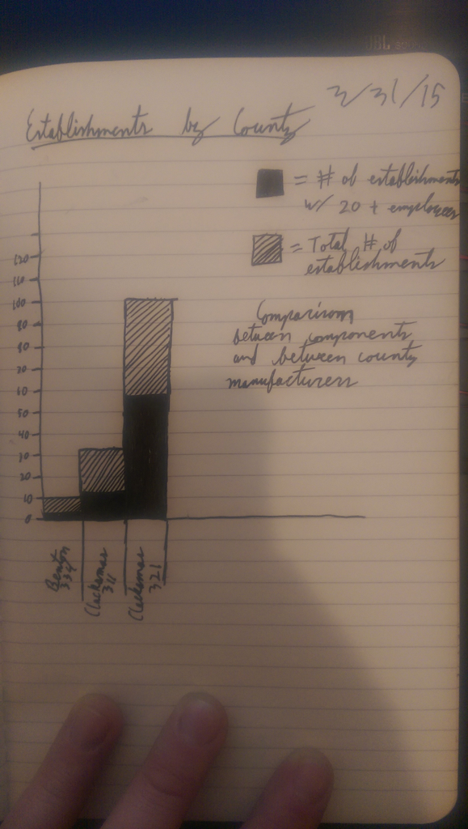

bertin exercise example

## The Invariant

The invariant is represented by the title

## The components

The components are the things that vary in the graphic

## Retinal Variables

The retinal variables are the things that form an image on our retinas

## Bertin’s Theory

It should not be surprising that information design owes so much to a cartographer. This is one of two fields, the other being social network analysis, with the most influence on building information containers today. The remaining sections of this chapter explore Bertin’s theory of information graphics.

## Theories

The word theory is used to mean many things. To obtain a useful definition, it might be helpful to consider what Stephen Hawking says about theory in *A Brief History of Time* on page 7.

*A theory is a good theory if it satisfies two requirements. It must accurately describe a large class of observations on the basis of a model that contains only a few arbitrary elements, and it must make definite predictions about the results of future observations. For example, Aristotle believed Empedocles’s theory that everything was made out of four elements: earth, air, fire, and water. This was simple enough, but did not make any definite predictions. On the other hand, Newton’s theory of gravity was based on an even simpler model, in which bodies attracted each other with a force that was proportional to a quantity called their mass and inversely proportional to the square of the distance between them. Yet it predicts the motions of the sun, the moon, and the planets to a high degree of accuracy.*

## Efficiency

Bertin defines efficiency as a measure of how quickly the process of reading a graphic can be completed and defines the process in some detail under the influence of (then) contemporary philosophy. Let’s read some information graphics now to get an idea of what this might entail.

## Categories of information graphics

Bertin describes four categories of graphics: diagrams, networks, maps, and symbols. It is the use of the last three categories, coupled with the detail in Bertin’s theory, that persuade me that here is a good foundation for describing information architecture.

## Symbols

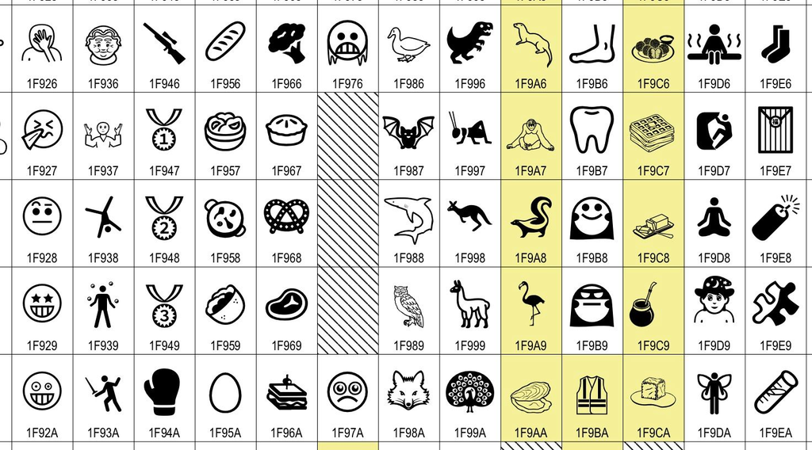

## Diagrams

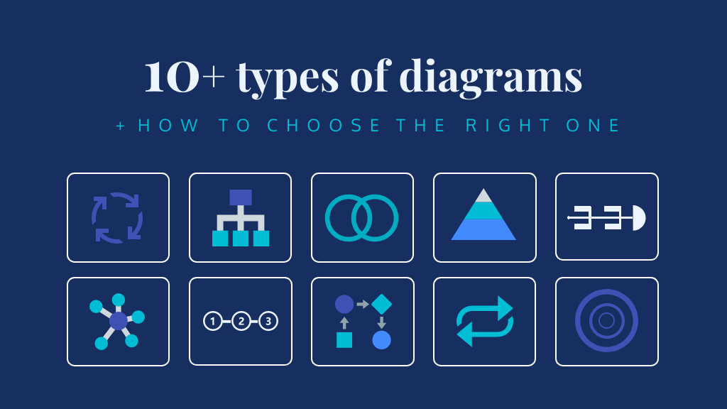

## Networks

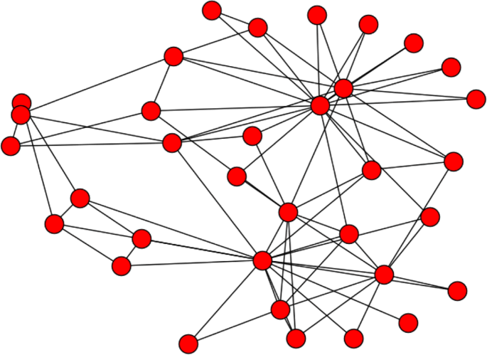

## Maps

[figure not shown]

## Simplification

[figure not shown]

A Picasso nude exemplifies simplicity

## Example: Swim lane diagrams

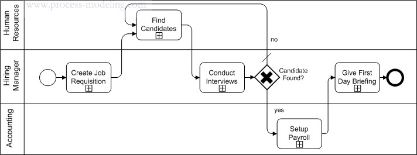

# Visual Design of Information

## Different perspectives drive different views

When we analyze what people see, we bring a perspective, in part based on where we are and what we do. Think about some bases for your perspective on the visible variables in presenting information, such as professional, cultural and biological.

## An important perspective

*When art critics get together they talk about Form and Structure and Meaning. When artists get together they talk about where you can buy cheap turpentine.*

— Pablo Picasso

quoted by Steve McConnell, *Code Complete* (1993)

## Another perspective

*Modern philosophers have had little to say about the nature of aesthetic interest; … The concentration has been on the philosophy of art, and in particular on puzzles created by boring impostors like Duchamp: is this signed urinal a work of art? etc. This makes for an exceedingly dull literature, devoted to questions which can be answered in any way while leaving everything important exactly as it is.*

—Roger Scruton, *Modern Philosophy* (1994), p. 589

## Essence

[figure not shown]

Picasso’s Bull Lithographs

## More on Essence

[figure not shown]

## Gestalt principles

- proximity: proximate images form a group
- similarity: similar images form a group
- closure: perception completes images that appear to have missing parts
- symmetry: perception links unconnected symmetric images
- common fate: images perceived to have common fate (follow a path) form a group
- continuity: continuous images form a group
- prägnanz: images that seem to work well together form a group

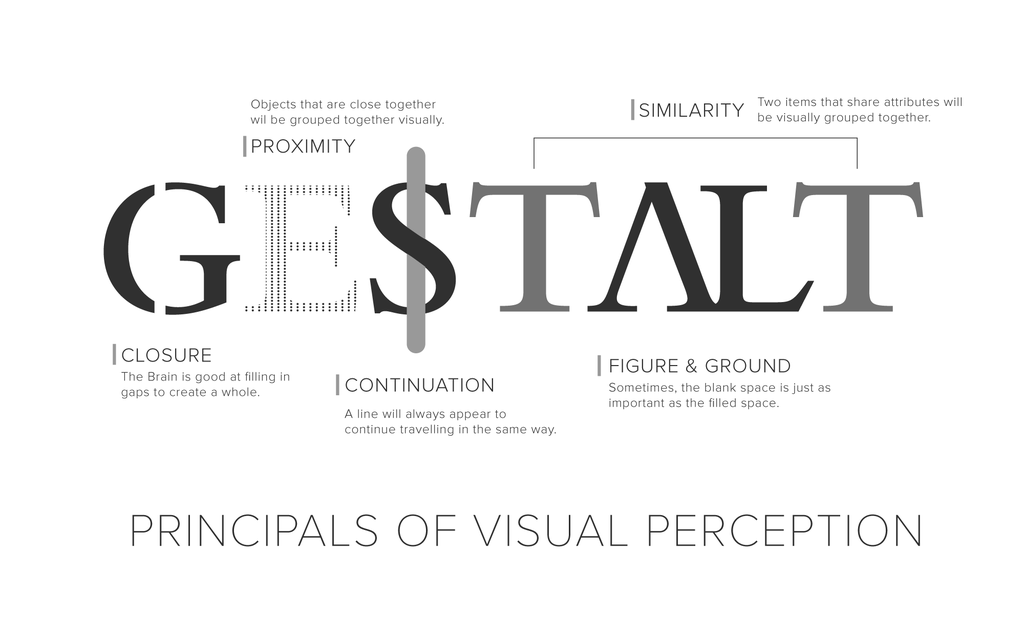

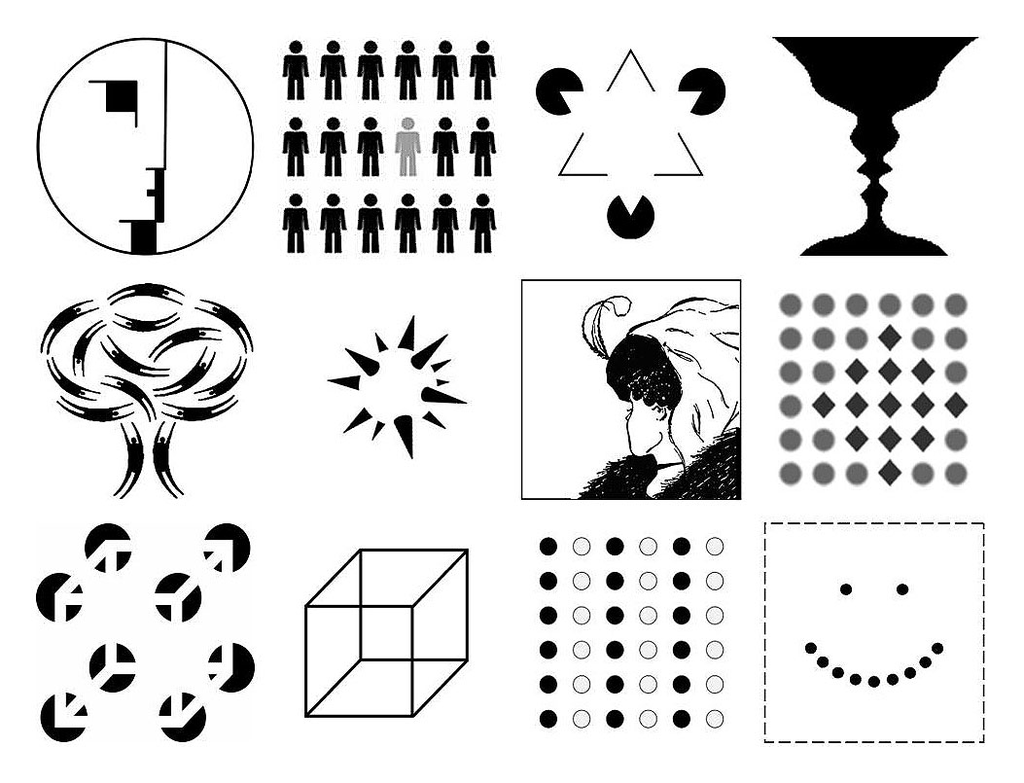

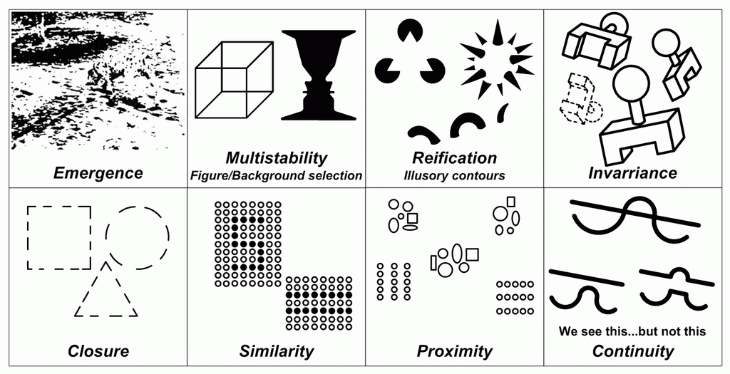

## Dieter Rams

- Good design is innovative.
- Good design makes a product useful.
- Good design is aesthetic.
- Good design helps us to understand a product.
- Good design is unobtrusive.
- Good design is honest.
- Good design is durable.
- Good design is consequent to the last detail.
- Good design is concerned with the environment.
- Good design is as little design as possible.

## Edward Tufte

- Comparisons–Show comparisons, contrasts, differences
- Causality, Mechanism, Structure, Explanation
- Multivariate Analysis—Show more than 1 or 2 variables
- Integration of Evidence—Integrate words, numbers, images, diagrams
- Documentation—label what data you have and measurements, etc.
- Content Counts Most of All—depend on quality, relevance, and integrity

## Contemporary Perspectives on Design Principles

## Get a GRIP and forget about CRAP

- grouping: group like elements together; separate disparate elements
- restatement: clarify meaning by repetition
- implied lines: align objects to minimize visual distraction
- popout: make some objects appear more prominently than others

# Visual Information Components

- Color
- Typography
- Layout
- Animation

We explored these when surveying prototyping in week 7.

# END

# References

Bertin, Jacques. 2011. *Semiology of Graphics: Diagrams, Networks, Maps (English Translation)*. ESRI Press.

Tufte, Edward R. 2001. *The Visual Display of Quantitative Information*. Graphics Press.

# Colophon

This slideshow was produced using `quarto`

Fonts are *Fira Sans*, *Fira Sans Light*, and *Victor Mono Nerd Font*

Math is set in *Fira Math* via *MathJax 4*